# Example Usage: Direct Use of Semi-Parametric Routines

## Introduction

Here we show how to directly use the Semiparametric routines while bypassing the "trainOutlierDetector" routine.

The data used in this example is from the 3-story structure. More details about the data sets can be found in 3-Story Data Sets.

Requires data3SS.mat dataset.

SHMTools functions called:

- arModel_shm
- learnGMMSemiParametricModel_shm
- scoreGMM_shm

Author: Samory Kpotufe

Date Created: August 19, 2009

LA-CC-14-046  
Copyright (c) 2014, Los Alamos National Security, LLC  
All rights reserved.

```python
import numpy as np
import matplotlib.pyplot as plt
from scipy import stats
from shmtools.features import ar_model_shm
from shmtools.classification import (
    learn_gmm_semiparametric_model_shm,
    score_gmm_shm,
    score_gmm_semiparametric_model_shm,
    k_medians_shm,
    roc_shm
)
from shmtools.utils.data_loading import load_3story_data
```

## Load data

The data here is in the form of time series in a 3 dimensional matrix (time, sensors, instances) and also a state vector representing the various environmental conditions under which the data is collected.

```python
data = load_3story_data()
dataset = data['dataset']
states = data['damage_states']
```

For this example, we will break each 8192 point time series into 4, 2048 point time series.

```python
time_data = np.zeros((2048, 5, 680))
time_data_states = np.zeros(680)
for i in range(4):
    start_idx = 2048 * i
    end_idx = 2048 * (i + 1)
    time_data[:, :, i::4] = dataset[start_idx:end_idx, :, :]
    time_data_states[i::4] = states
```

Extract some features using your favorite function, but first pick N of the instances (each time series reading over all sensors). Each instance is then transformed into a feature vector: the returned matrix has the form (instances, features).

```python
N = 400
np.random.seed(42)  # For reproducibility
idx = np.random.permutation(time_data.shape[2])[:N]
X_data = ar_model_shm(time_data[:, :, idx])[1]  # Get RMS residuals feature vector
X_states = time_data_states[idx]
```

Now set 80% of states 1:9 aside as the training data, these states correspond to undamaged readings. We'll then test on the remaining 20% of 1:9 and on the "damaged" states 10:17.

```python
idx = np.isin(X_states, range(1, 10))  # States 1:9
X_undamaged = X_data[idx, :]
n_undamaged = X_undamaged.shape[0]
n_train = round(0.8 * n_undamaged)
X_train = X_undamaged[:n_train, :]
X_test = np.vstack([X_undamaged[n_train:, :], X_data[~idx, :]])
n_test = X_test.shape[0]
```

Now set labels for the test data, 0 corresponds to undamaged, and 1 to damaged.

number of undamaged in test.

```python
n_test_0 = n_undamaged - n_train
```

test labels

```python
test_labels = np.concatenate([np.zeros(n_test_0), np.ones(n_test - n_test_0)])
```

## Train a model over the undamaged data

The next call learns a mixture of k gaussians over the undamaged data and returns the parameters of this model in dModel. The partition function is one of those in "SemiParametricDetectors/PartitioningAlgorithms/" or should have the same behavior as one of those functions (including signature). The "MMFun" is a Mixture Model function from "SemiParametricDetectors/ParametricMixtures" or should have the same behavior.

```python
partition_fun = k_medians_shm
k = 5
d_model = learn_gmm_semiparametric_model_shm(X_train, partition_fun, k)
```

## Pick a threshold from the training data

We will first obtain the "scores" over the training data, that is the log-likelihoods that are given by the learned distribution. Then we learn a distribution of these scores, and pick a threshold so that 90% of the training data (undamaged data) has scores above this threshold (according to the distribution of scores).

```python
likelihoods = score_gmm_shm(X_train, d_model)
```

learn a normal distribution over the scores

```python
model_p = stats.norm.fit(likelihoods)
```

pick the threshold

```python
confidence = 0.9
threshold = stats.norm.ppf(1 - confidence, model_p[0], model_p[1])
```

## Test the detector

Now the detector consists simply of getting the distribution of scores over the test data, under the distribution learned on the undamaged training data (dModel). We simply flag a test point as "damaged" whenever it falls below our threshold.

Test scores

```python
scores = score_gmm_semiparametric_model_shm(X_test, d_model)
```

Results contains a 1 whenever we think the point is damaged, a 0 otherwise.

```python
results = scores <= threshold
```

## Report the detector's performance

Various error rates

```python
total_err = np.sum(results != test_labels) / n_test
false_positive_err = np.sum(results[:n_test_0] != 0) / n_test_0
false_negative_err = np.sum(results[n_test_0:] != 1) / (n_test - n_test_0)
print(f'\n Total error: {total_err:.2f}\n False Positive rate: {false_positive_err:.2f}\n False Negative rate: {false_negative_err:.2f}')
```

```
 Total error: 0.09
 False Positive rate: 0.20
 False Negative rate: 0.06
```

ROC curve

```python
true_positives, false_positives = roc_shm(scores, test_labels)
```

Now plot the curve

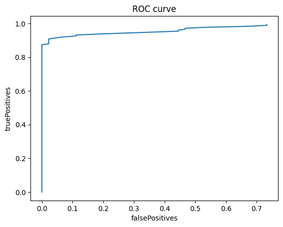

```python
plt.figure()
plt.plot(false_positives, true_positives)
plt.xlabel('falsePositives')
plt.ylabel('truePositives')
plt.title('ROC curve')
plt.show()
```